# Risk Factor Analysis

## Outcome Variable

**Outcome Variable:** ever_wasted

## Predictor Variables

**Intervention Variable:** meducyrs

**Adjustment Set:**

- arm
- W_mage
- feducyrs
- hhwealth_quart
- W_mhtcm
- W_mwtkg
- W_mbmi
- W_gagebrth
- W_birthwt
- W_birthlen
- single
- impsan
- delta_W_mage
- delta_feducyrs
- delta_hhwealth_quart
- delta_W_mhtcm
- delta_W_mwtkg
- delta_W_mbmi
- delta_W_gagebrth
- delta_W_birthwt
- delta_W_birthlen
- delta_single
- delta_impsan

## Stratifying Variables

The analysis was stratified on these variable(s):

- agecat
- studyid
- country

## Data Summary

| agecat | studyid | country | meducyrs | ever_wasted | n_cell | n |
| --- | --- | --- | --- | --- | --- | --- |
| 0-24 months | CMC-V-BCS-2002 | INDIA | High | 0 | 69 | 373 |
| 0-24 months | CMC-V-BCS-2002 | INDIA | High | 1 | 89 | 373 |
| 0-24 months | CMC-V-BCS-2002 | INDIA | Low | 0 | 38 | 373 |
| 0-24 months | CMC-V-BCS-2002 | INDIA | Low | 1 | 68 | 373 |
| 0-24 months | CMC-V-BCS-2002 | INDIA | Medium | 0 | 38 | 373 |
| 0-24 months | CMC-V-BCS-2002 | INDIA | Medium | 1 | 71 | 373 |
| 0-24 months | COHORTS | GUATEMALA | High | 0 | 218 | 1322 |
| 0-24 months | COHORTS | GUATEMALA | High | 1 | 62 | 1322 |
| 0-24 months | COHORTS | GUATEMALA | Low | 0 | 465 | 1322 |
| 0-24 months | COHORTS | GUATEMALA | Low | 1 | 162 | 1322 |
| 0-24 months | COHORTS | GUATEMALA | Medium | 0 | 300 | 1322 |
| 0-24 months | COHORTS | GUATEMALA | Medium | 1 | 115 | 1322 |
| 0-24 months | COHORTS | INDIA | High | 0 | 596 | 5844 |
| 0-24 months | COHORTS | INDIA | High | 1 | 197 | 5844 |
| 0-24 months | COHORTS | INDIA | Low | 0 | 1175 | 5844 |
| 0-24 months | COHORTS | INDIA | Low | 1 | 776 | 5844 |
| 0-24 months | COHORTS | INDIA | Medium | 0 | 2127 | 5844 |
| 0-24 months | COHORTS | INDIA | Medium | 1 | 973 | 5844 |
| 0-24 months | COHORTS | PHILIPPINES | High | 0 | 727 | 3045 |
| 0-24 months | COHORTS | PHILIPPINES | High | 1 | 441 | 3045 |
| 0-24 months | COHORTS | PHILIPPINES | Low | 0 | 496 | 3045 |
| 0-24 months | COHORTS | PHILIPPINES | Low | 1 | 405 | 3045 |
| 0-24 months | COHORTS | PHILIPPINES | Medium | 0 | 593 | 3045 |
| 0-24 months | COHORTS | PHILIPPINES | Medium | 1 | 383 | 3045 |
| 0-24 months | EE | PAKISTAN | High | 0 | 7 | 377 |
| 0-24 months | EE | PAKISTAN | High | 1 | 8 | 377 |
| 0-24 months | EE | PAKISTAN | Low | 0 | 129 | 377 |
| 0-24 months | EE | PAKISTAN | Low | 1 | 200 | 377 |
| 0-24 months | EE | PAKISTAN | Medium | 0 | 18 | 377 |
| 0-24 months | EE | PAKISTAN | Medium | 1 | 15 | 377 |

[output cut: 438 more lines]

The following strata were considered:

- agecat: 0-24 months, studyid: CMC-V-BCS-2002, country: INDIA
- agecat: 0-24 months, studyid: COHORTS, country: GUATEMALA
- agecat: 0-24 months, studyid: COHORTS, country: INDIA
- agecat: 0-24 months, studyid: COHORTS, country: PHILIPPINES
- agecat: 0-24 months, studyid: EE, country: PAKISTAN
- agecat: 0-24 months, studyid: GMS-Nepal, country: NEPAL
- agecat: 0-24 months, studyid: Guatemala BSC, country: GUATEMALA
- agecat: 0-24 months, studyid: IRC, country: INDIA
- agecat: 0-24 months, studyid: JiVitA-3, country: BANGLADESH
- agecat: 0-24 months, studyid: JiVitA-4, country: BANGLADESH
- agecat: 0-24 months, studyid: LCNI-5, country: MALAWI
- agecat: 0-24 months, studyid: MAL-ED, country: BANGLADESH
- agecat: 0-24 months, studyid: MAL-ED, country: BRAZIL
- agecat: 0-24 months, studyid: MAL-ED, country: INDIA
- agecat: 0-24 months, studyid: MAL-ED, country: NEPAL
- agecat: 0-24 months, studyid: MAL-ED, country: PERU
- agecat: 0-24 months, studyid: MAL-ED, country: SOUTH AFRICA
- agecat: 0-24 months, studyid: MAL-ED, country: TANZANIA, UNITED REPUBLIC OF
- agecat: 0-24 months, studyid: NIH-Birth, country: BANGLADESH
- agecat: 0-24 months, studyid: NIH-Crypto, country: BANGLADESH
- agecat: 0-24 months, studyid: PROBIT, country: BELARUS
- agecat: 0-24 months, studyid: PROVIDE, country: BANGLADESH
- agecat: 0-24 months, studyid: SAS-CompFeed, country: INDIA
- agecat: 0-24 months, studyid: SAS-FoodSuppl, country: INDIA
- agecat: 0-24 months, studyid: TanzaniaChild2, country: TANZANIA, UNITED REPUBLIC OF
- agecat: 0-24 months, studyid: ZVITAMBO, country: ZIMBABWE
- agecat: 0-6 months, studyid: CMC-V-BCS-2002, country: INDIA
- agecat: 0-6 months, studyid: COHORTS, country: GUATEMALA
- agecat: 0-6 months, studyid: COHORTS, country: INDIA
- agecat: 0-6 months, studyid: COHORTS, country: PHILIPPINES
- agecat: 0-6 months, studyid: EE, country: PAKISTAN
- agecat: 0-6 months, studyid: GMS-Nepal, country: NEPAL
- agecat: 0-6 months, studyid: Guatemala BSC, country: GUATEMALA
- agecat: 0-6 months, studyid: IRC, country: INDIA
- agecat: 0-6 months, studyid: JiVitA-3, country: BANGLADESH
- agecat: 0-6 months, studyid: JiVitA-4, country: BANGLADESH
- agecat: 0-6 months, studyid: LCNI-5, country: MALAWI
- agecat: 0-6 months, studyid: MAL-ED, country: BANGLADESH
- agecat: 0-6 months, studyid: MAL-ED, country: BRAZIL
- agecat: 0-6 months, studyid: MAL-ED, country: INDIA
- agecat: 0-6 months, studyid: MAL-ED, country: NEPAL
- agecat: 0-6 months, studyid: MAL-ED, country: PERU
- agecat: 0-6 months, studyid: MAL-ED, country: SOUTH AFRICA
- agecat: 0-6 months, studyid: MAL-ED, country: TANZANIA, UNITED REPUBLIC OF
- agecat: 0-6 months, studyid: NIH-Birth, country: BANGLADESH
- agecat: 0-6 months, studyid: NIH-Crypto, country: BANGLADESH
- agecat: 0-6 months, studyid: PROBIT, country: BELARUS
- agecat: 0-6 months, studyid: PROVIDE, country: BANGLADESH
- agecat: 0-6 months, studyid: SAS-CompFeed, country: INDIA
- agecat: 0-6 months, studyid: SAS-FoodSuppl, country: INDIA
- agecat: 0-6 months, studyid: TanzaniaChild2, country: TANZANIA, UNITED REPUBLIC OF
- agecat: 0-6 months, studyid: ZVITAMBO, country: ZIMBABWE
- agecat: 6-24 months, studyid: CMC-V-BCS-2002, country: INDIA
- agecat: 6-24 months, studyid: COHORTS, country: GUATEMALA
- agecat: 6-24 months, studyid: COHORTS, country: INDIA
- agecat: 6-24 months, studyid: COHORTS, country: PHILIPPINES
- agecat: 6-24 months, studyid: EE, country: PAKISTAN
- agecat: 6-24 months, studyid: GMS-Nepal, country: NEPAL
- agecat: 6-24 months, studyid: Guatemala BSC, country: GUATEMALA
- agecat: 6-24 months, studyid: IRC, country: INDIA
- agecat: 6-24 months, studyid: JiVitA-3, country: BANGLADESH
- agecat: 6-24 months, studyid: JiVitA-4, country: BANGLADESH
- agecat: 6-24 months, studyid: LCNI-5, country: MALAWI
- agecat: 6-24 months, studyid: MAL-ED, country: BANGLADESH
- agecat: 6-24 months, studyid: MAL-ED, country: BRAZIL
- agecat: 6-24 months, studyid: MAL-ED, country: INDIA
- agecat: 6-24 months, studyid: MAL-ED, country: NEPAL
- agecat: 6-24 months, studyid: MAL-ED, country: PERU
- agecat: 6-24 months, studyid: MAL-ED, country: SOUTH AFRICA
- agecat: 6-24 months, studyid: MAL-ED, country: TANZANIA, UNITED REPUBLIC OF
- agecat: 6-24 months, studyid: NIH-Birth, country: BANGLADESH
- agecat: 6-24 months, studyid: NIH-Crypto, country: BANGLADESH
- agecat: 6-24 months, studyid: PROBIT, country: BELARUS
- agecat: 6-24 months, studyid: PROVIDE, country: BANGLADESH
- agecat: 6-24 months, studyid: SAS-CompFeed, country: INDIA
- agecat: 6-24 months, studyid: SAS-FoodSuppl, country: INDIA
- agecat: 6-24 months, studyid: TanzaniaChild2, country: TANZANIA, UNITED REPUBLIC OF
- agecat: 6-24 months, studyid: ZVITAMBO, country: ZIMBABWE

### Dropped Strata

Some strata were dropped due to rare outcomes:

- agecat: 0-24 months, studyid: MAL-ED, country: BRAZIL
- agecat: 0-24 months, studyid: MAL-ED, country: PERU
- agecat: 0-24 months, studyid: MAL-ED, country: TANZANIA, UNITED REPUBLIC OF
- agecat: 0-6 months, studyid: EE, country: PAKISTAN
- agecat: 0-6 months, studyid: Guatemala BSC, country: GUATEMALA
- agecat: 0-6 months, studyid: LCNI-5, country: MALAWI
- agecat: 0-6 months, studyid: MAL-ED, country: BRAZIL
- agecat: 0-6 months, studyid: MAL-ED, country: PERU
- agecat: 0-6 months, studyid: MAL-ED, country: TANZANIA, UNITED REPUBLIC OF
- agecat: 0-6 months, studyid: SAS-FoodSuppl, country: INDIA
- agecat: 6-24 months, studyid: Guatemala BSC, country: GUATEMALA
- agecat: 6-24 months, studyid: MAL-ED, country: BRAZIL
- agecat: 6-24 months, studyid: MAL-ED, country: PERU
- agecat: 6-24 months, studyid: MAL-ED, country: TANZANIA, UNITED REPUBLIC OF

## Methods Detail

We’re interested in the causal parameters $E[Y_a]$ for all values of $a \in \mathcal{A}$. These parameters represent the mean outcome if, possibly contrary to fact, we intervened to set all units to have $A=a$. Under the randomization and positivity assumptions, these are identified by the statistical parameters $\psi_a=E_W[E_{Y|A,W}(Y|A=a,W)]$. In addition, we’re interested in the mean of $Y$, $E[Y]$ under no intervention (the observed mean). We will estimate these parameters by using SuperLearner to fit the relevant likelihood factors – $E_{Y|A,W}(Y|A=a,W)$ and $p(A=a|W)$, and then updating our likelihood fit using a joint TMLE.

For unadjusted analyses ($W=\{\}$), initial likelihoods were estimated using Lrnr_glm to estimate the simple $E(Y|A)$ and Lrnr_mean to estimate $p(A)$. For adjusted analyses, a small library containing Lrnr_glmnet, Lrnr_xgboost, and Lrnr_mean was used.

Having estimated these parameters, we will then use the delta method to estimate relative risks and attributable risks relative to a prespecified baseline level of $A$.

# Results Detail

## Results Plots

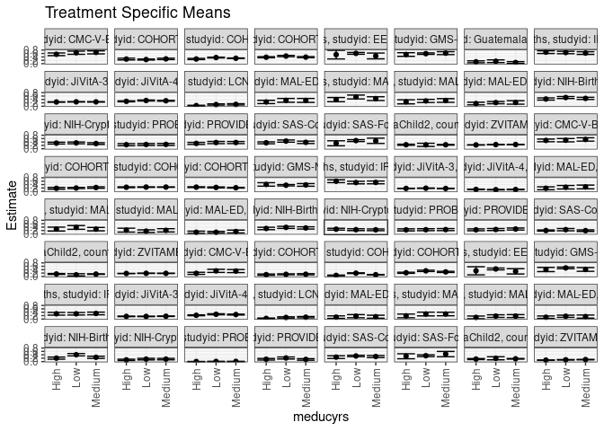

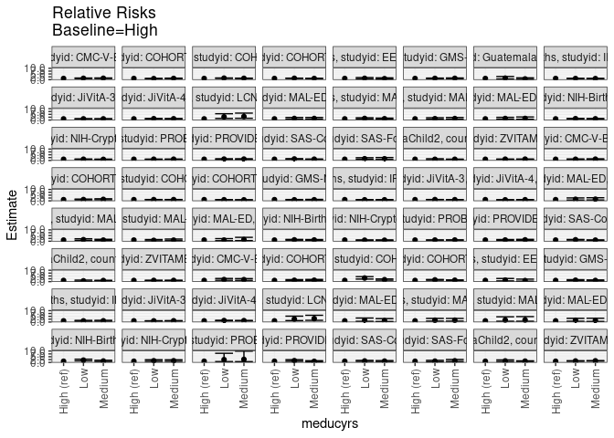

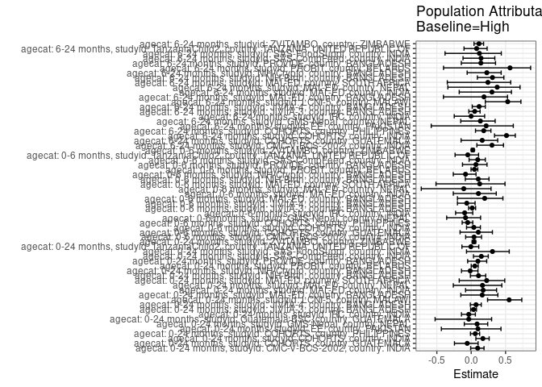

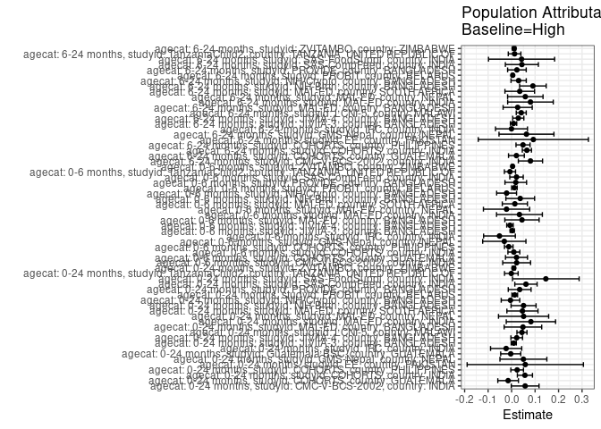

## Results Table

### Parameter: TSM

| agecat | studyid | country | intervention_level | baseline_level | estimate | ci_lower | ci_upper |
| --- | --- | --- | --- | --- | --- | --- | --- |
| 0-24 months | CMC-V-BCS-2002 | INDIA | High | NA | 0.5535636 | 0.4753983 | 0.6317290 |
| 0-24 months | CMC-V-BCS-2002 | INDIA | Low | NA | 0.6442377 | 0.5516777 | 0.7367976 |
| 0-24 months | CMC-V-BCS-2002 | INDIA | Medium | NA | 0.6654824 | 0.5760012 | 0.7549636 |
| 0-24 months | COHORTS | GUATEMALA | High | NA | 0.2712625 | 0.2213037 | 0.3212213 |
| 0-24 months | COHORTS | GUATEMALA | Low | NA | 0.2437361 | 0.2118547 | 0.2756176 |
| 0-24 months | COHORTS | GUATEMALA | Medium | NA | 0.2822616 | 0.2426765 | 0.3218468 |
| 0-24 months | COHORTS | INDIA | High | NA | 0.2762977 | 0.2426731 | 0.3099223 |
| 0-24 months | COHORTS | INDIA | Low | NA | 0.3602985 | 0.3375237 | 0.3830733 |
| 0-24 months | COHORTS | INDIA | Medium | NA | 0.3188008 | 0.3030099 | 0.3345917 |
| 0-24 months | COHORTS | PHILIPPINES | High | NA | 0.3800158 | 0.3484949 | 0.4115367 |
| 0-24 months | COHORTS | PHILIPPINES | Low | NA | 0.4476623 | 0.4100842 | 0.4852403 |
| 0-24 months | COHORTS | PHILIPPINES | Medium | NA | 0.3857456 | 0.3533732 | 0.4181181 |
| 0-24 months | EE | PAKISTAN | High | NA | 0.5333333 | 0.2805305 | 0.7861362 |
| 0-24 months | EE | PAKISTAN | Low | NA | 0.6079027 | 0.5550776 | 0.6607279 |
| 0-24 months | EE | PAKISTAN | Medium | NA | 0.4545455 | 0.2844331 | 0.6246578 |
| 0-24 months | GMS-Nepal | NEPAL | High | NA | 0.5397608 | 0.4327801 | 0.6467415 |
| 0-24 months | GMS-Nepal | NEPAL | Low | NA | 0.5918502 | 0.5488229 | 0.6348775 |
| 0-24 months | GMS-Nepal | NEPAL | Medium | NA | 0.6196326 | 0.5319530 | 0.7073123 |
| 0-24 months | Guatemala BSC | GUATEMALA | High | NA | 0.1101695 | 0.0535765 | 0.1667625 |
| 0-24 months | Guatemala BSC | GUATEMALA | Low | NA | 0.1447368 | 0.0654954 | 0.2239782 |
| 0-24 months | Guatemala BSC | GUATEMALA | Medium | NA | 0.0681818 | 0.0154251 | 0.1209386 |
| 0-24 months | IRC | INDIA | High | NA | 0.6794008 | 0.5982182 | 0.7605834 |
| 0-24 months | IRC | INDIA | Low | NA | 0.6573549 | 0.5863207 | 0.7283892 |
| 0-24 months | IRC | INDIA | Medium | NA | 0.6248319 | 0.5460127 | 0.7036511 |
| 0-24 months | JiVitA-3 | BANGLADESH | High | NA | 0.2489217 | 0.2365360 | 0.2613074 |
| 0-24 months | JiVitA-3 | BANGLADESH | Low | NA | 0.2591372 | 0.2470793 | 0.2711951 |
| 0-24 months | JiVitA-3 | BANGLADESH | Medium | NA | 0.2570110 | 0.2435311 | 0.2704910 |
| 0-24 months | JiVitA-4 | BANGLADESH | High | NA | 0.2887857 | 0.2610555 | 0.3165158 |
| 0-24 months | JiVitA-4 | BANGLADESH | Low | NA | 0.3373313 | 0.3072924 | 0.3673702 |
| 0-24 months | JiVitA-4 | BANGLADESH | Medium | NA | 0.3224561 | 0.2970507 | 0.3478614 |

[output cut: 162 more lines]

### Parameter: E(Y)

| agecat | studyid | country | intervention_level | baseline_level | estimate | ci_lower | ci_upper |
| --- | --- | --- | --- | --- | --- | --- | --- |
| 0-24 months | CMC-V-BCS-2002 | INDIA | NA | NA | 0.6112601 | 0.5617242 | 0.6607959 |
| 0-24 months | COHORTS | GUATEMALA | NA | NA | 0.2564297 | 0.2328823 | 0.2799770 |
| 0-24 months | COHORTS | INDIA | NA | NA | 0.3329911 | 0.3209071 | 0.3450751 |
| 0-24 months | COHORTS | PHILIPPINES | NA | NA | 0.4036125 | 0.3861835 | 0.4210415 |
| 0-24 months | EE | PAKISTAN | NA | NA | 0.5915119 | 0.5418269 | 0.6411970 |
| 0-24 months | GMS-Nepal | NEPAL | NA | NA | 0.5900439 | 0.5531320 | 0.6269559 |
| 0-24 months | Guatemala BSC | GUATEMALA | NA | NA | 0.1063830 | 0.0703329 | 0.1424331 |
| 0-24 months | IRC | INDIA | NA | NA | 0.6560976 | 0.6100625 | 0.7021326 |
| 0-24 months | JiVitA-3 | BANGLADESH | NA | NA | 0.2580418 | 0.2515722 | 0.2645113 |
| 0-24 months | JiVitA-4 | BANGLADESH | NA | NA | 0.3105166 | 0.2961054 | 0.3249278 |
| 0-24 months | LCNI-5 | MALAWI | NA | NA | 0.0798526 | 0.0612199 | 0.0984853 |
| 0-24 months | MAL-ED | BANGLADESH | NA | NA | 0.3004695 | 0.2387555 | 0.3621835 |
| 0-24 months | MAL-ED | INDIA | NA | NA | 0.4727273 | 0.4066048 | 0.5388497 |
| 0-24 months | MAL-ED | NEPAL | NA | NA | 0.3111111 | 0.2504855 | 0.3717368 |
| 0-24 months | MAL-ED | SOUTH AFRICA | NA | NA | 0.2051282 | 0.1602507 | 0.2500058 |
| 0-24 months | NIH-Birth | BANGLADESH | NA | NA | 0.4775641 | 0.4383415 | 0.5167867 |
| 0-24 months | NIH-Crypto | BANGLADESH | NA | NA | 0.3298153 | 0.2963239 | 0.3633067 |
| 0-24 months | PROBIT | BELARUS | NA | NA | 0.2554148 | 0.1971257 | 0.3137039 |
| 0-24 months | PROVIDE | BANGLADESH | NA | NA | 0.3514286 | 0.3160364 | 0.3868207 |
| 0-24 months | SAS-CompFeed | INDIA | NA | NA | 0.4150694 | 0.3581204 | 0.4720184 |
| 0-24 months | SAS-FoodSuppl | INDIA | NA | NA | 0.4712919 | 0.4233811 | 0.5192026 |
| 0-24 months | TanzaniaChild2 | TANZANIA, UNITED REPUBLIC OF | NA | NA | 0.2367980 | 0.2197367 | 0.2538593 |
| 0-24 months | ZVITAMBO | ZIMBABWE | NA | NA | 0.2366078 | 0.2295489 | 0.2436667 |
| 0-6 months | CMC-V-BCS-2002 | INDIA | NA | NA | 0.5163043 | 0.4651769 | 0.5674318 |
| 0-6 months | COHORTS | GUATEMALA | NA | NA | 0.2007612 | 0.1765324 | 0.2249900 |
| 0-6 months | COHORTS | INDIA | NA | NA | 0.2511554 | 0.2398221 | 0.2624886 |
| 0-6 months | COHORTS | PHILIPPINES | NA | NA | 0.2355453 | 0.2204685 | 0.2506222 |
| 0-6 months | GMS-Nepal | NEPAL | NA | NA | 0.3762811 | 0.3399226 | 0.4126397 |
| 0-6 months | IRC | INDIA | NA | NA | 0.5439024 | 0.4956326 | 0.5921723 |
| 0-6 months | JiVitA-3 | BANGLADESH | NA | NA | 0.1762162 | 0.1705869 | 0.1818456 |
| 0-6 months | JiVitA-4 | BANGLADESH | NA | NA | 0.1079378 | 0.0980978 | 0.1177778 |
| 0-6 months | MAL-ED | BANGLADESH | NA | NA | 0.2253521 | 0.1691098 | 0.2815944 |
| 0-6 months | MAL-ED | INDIA | NA | NA | 0.3181818 | 0.2564942 | 0.3798694 |
| 0-6 months | MAL-ED | NEPAL | NA | NA | 0.2000000 | 0.1476178 | 0.2523822 |
| 0-6 months | MAL-ED | SOUTH AFRICA | NA | NA | 0.1121795 | 0.0771053 | 0.1472536 |
| 0-6 months | NIH-Birth | BANGLADESH | NA | NA | 0.3569132 | 0.3192325 | 0.3945938 |
| 0-6 months | NIH-Crypto | BANGLADESH | NA | NA | 0.2572559 | 0.2261171 | 0.2883948 |
| 0-6 months | PROBIT | BELARUS | NA | NA | 0.2500148 | 0.1915461 | 0.3084835 |
| 0-6 months | PROVIDE | BANGLADESH | NA | NA | 0.2585714 | 0.2261125 | 0.2910304 |
| 0-6 months | SAS-CompFeed | INDIA | NA | NA | 0.2199336 | 0.1753445 | 0.2645227 |
| 0-6 months | TanzaniaChild2 | TANZANIA, UNITED REPUBLIC OF | NA | NA | 0.1395641 | 0.1256566 | 0.1534717 |
| 0-6 months | ZVITAMBO | ZIMBABWE | NA | NA | 0.1810164 | 0.1745999 | 0.1874330 |
| 6-24 months | CMC-V-BCS-2002 | INDIA | NA | NA | 0.2654155 | 0.2205451 | 0.3102860 |
| 6-24 months | COHORTS | GUATEMALA | NA | NA | 0.1277129 | 0.1088047 | 0.1466210 |
| 6-24 months | COHORTS | INDIA | NA | NA | 0.1266655 | 0.1178579 | 0.1354730 |
| 6-24 months | COHORTS | PHILIPPINES | NA | NA | 0.2666429 | 0.2502871 | 0.2829988 |
| 6-24 months | EE | PAKISTAN | NA | NA | 0.4258760 | 0.3754921 | 0.4762599 |
| 6-24 months | GMS-Nepal | NEPAL | NA | NA | 0.4735945 | 0.4331684 | 0.5140207 |
| 6-24 months | IRC | INDIA | NA | NA | 0.3097561 | 0.2649438 | 0.3545684 |
| 6-24 months | JiVitA-3 | BANGLADESH | NA | NA | 0.1638889 | 0.1577625 | 0.1700152 |
| 6-24 months | JiVitA-4 | BANGLADESH | NA | NA | 0.2475997 | 0.2340658 | 0.2611337 |
| 6-24 months | LCNI-5 | MALAWI | NA | NA | 0.0772105 | 0.0587369 | 0.0956840 |
| 6-24 months | MAL-ED | BANGLADESH | NA | NA | 0.1384615 | 0.0898601 | 0.1870630 |
| 6-24 months | MAL-ED | INDIA | NA | NA | 0.2657005 | 0.2053824 | 0.3260185 |
| 6-24 months | MAL-ED | NEPAL | NA | NA | 0.1545455 | 0.1066715 | 0.2024194 |
| 6-24 months | MAL-ED | SOUTH AFRICA | NA | NA | 0.1428571 | 0.1001583 | 0.1855560 |
| 6-24 months | NIH-Birth | BANGLADESH | NA | NA | 0.2933579 | 0.2549918 | 0.3317241 |
| 6-24 months | NIH-Crypto | BANGLADESH | NA | NA | 0.1315068 | 0.1069744 | 0.1560393 |
| 6-24 months | PROBIT | BELARUS | NA | NA | 0.0083745 | 0.0044130 | 0.0123360 |
| 6-24 months | PROVIDE | BANGLADESH | NA | NA | 0.1609756 | 0.1319065 | 0.1900447 |
| 6-24 months | SAS-CompFeed | INDIA | NA | NA | 0.3059755 | 0.2638053 | 0.3481458 |
| 6-24 months | SAS-FoodSuppl | INDIA | NA | NA | 0.3557214 | 0.3088651 | 0.4025777 |
| 6-24 months | TanzaniaChild2 | TANZANIA, UNITED REPUBLIC OF | NA | NA | 0.1606166 | 0.1445647 | 0.1766685 |
| 6-24 months | ZVITAMBO | ZIMBABWE | NA | NA | 0.0959259 | 0.0903717 | 0.1014802 |

### Parameter: RR

| agecat | studyid | country | intervention_level | baseline_level | estimate | ci_lower | ci_upper |
| --- | --- | --- | --- | --- | --- | --- | --- |
| 0-24 months | CMC-V-BCS-2002 | INDIA | High | High | 1.0000000 | 1.0000000 | 1.0000000 |
| 0-24 months | CMC-V-BCS-2002 | INDIA | Low | High | 1.1638006 | 0.9513645 | 1.4236729 |
| 0-24 months | CMC-V-BCS-2002 | INDIA | Medium | High | 1.2021787 | 0.9891104 | 1.4611450 |
| 0-24 months | COHORTS | GUATEMALA | High | High | 1.0000000 | 1.0000000 | 1.0000000 |
| 0-24 months | COHORTS | GUATEMALA | Low | High | 0.8985250 | 0.7261572 | 1.1118079 |
| 0-24 months | COHORTS | GUATEMALA | Medium | High | 1.0405479 | 0.8357421 | 1.2955432 |
| 0-24 months | COHORTS | INDIA | High | High | 1.0000000 | 1.0000000 | 1.0000000 |
| 0-24 months | COHORTS | INDIA | Low | High | 1.3040228 | 1.1410122 | 1.4903219 |
| 0-24 months | COHORTS | INDIA | Medium | High | 1.1538307 | 1.0164497 | 1.3097799 |
| 0-24 months | COHORTS | PHILIPPINES | High | High | 1.0000000 | 1.0000000 | 1.0000000 |
| 0-24 months | COHORTS | PHILIPPINES | Low | High | 1.1780096 | 1.0499898 | 1.3216382 |
| 0-24 months | COHORTS | PHILIPPINES | Medium | High | 1.0150779 | 0.9059863 | 1.1373054 |
| 0-24 months | EE | PAKISTAN | High | High | 1.0000000 | 1.0000000 | 1.0000000 |
| 0-24 months | EE | PAKISTAN | Low | High | 1.1398176 | 0.7039580 | 1.8455421 |
| 0-24 months | EE | PAKISTAN | Medium | High | 0.8522727 | 0.4658985 | 1.5590708 |
| 0-24 months | GMS-Nepal | NEPAL | High | High | 1.0000000 | 1.0000000 | 1.0000000 |
| 0-24 months | GMS-Nepal | NEPAL | Low | High | 1.0965045 | 0.8906453 | 1.3499449 |
| 0-24 months | GMS-Nepal | NEPAL | Medium | High | 1.1479763 | 0.9022572 | 1.4606142 |
| 0-24 months | Guatemala BSC | GUATEMALA | High | High | 1.0000000 | 1.0000000 | 1.0000000 |
| 0-24 months | Guatemala BSC | GUATEMALA | Low | High | 1.3137652 | 0.6201163 | 2.7833150 |
| 0-24 months | Guatemala BSC | GUATEMALA | Medium | High | 0.6188811 | 0.2444853 | 1.5666127 |
| 0-24 months | IRC | INDIA | High | High | 1.0000000 | 1.0000000 | 1.0000000 |
| 0-24 months | IRC | INDIA | Low | High | 0.9675510 | 0.8274539 | 1.1313681 |
| 0-24 months | IRC | INDIA | Medium | High | 0.9196808 | 0.7750874 | 1.0912482 |
| 0-24 months | JiVitA-3 | BANGLADESH | High | High | 1.0000000 | 1.0000000 | 1.0000000 |
| 0-24 months | JiVitA-3 | BANGLADESH | Low | High | 1.0410392 | 0.9778505 | 1.1083111 |
| 0-24 months | JiVitA-3 | BANGLADESH | Medium | High | 1.0324976 | 0.9633627 | 1.1065939 |
| 0-24 months | JiVitA-4 | BANGLADESH | High | High | 1.0000000 | 1.0000000 | 1.0000000 |
| 0-24 months | JiVitA-4 | BANGLADESH | Low | High | 1.1681027 | 1.0275943 | 1.3278236 |
| 0-24 months | JiVitA-4 | BANGLADESH | Medium | High | 1.1165931 | 0.9866253 | 1.2636814 |

[output cut: 162 more lines]

### Parameter: PAR

| agecat | studyid | country | intervention_level | baseline_level | estimate | ci_lower | ci_upper |
| --- | --- | --- | --- | --- | --- | --- | --- |
| 0-24 months | CMC-V-BCS-2002 | INDIA | High | NA | 0.0576964 | -0.0013563 | 0.1167492 |
| 0-24 months | COHORTS | GUATEMALA | High | NA | -0.0148328 | -0.0587419 | 0.0290762 |
| 0-24 months | COHORTS | INDIA | High | NA | 0.0566934 | 0.0245113 | 0.0888755 |
| 0-24 months | COHORTS | PHILIPPINES | High | NA | 0.0235967 | -0.0033459 | 0.0505392 |
| 0-24 months | EE | PAKISTAN | High | NA | 0.0581786 | -0.1893941 | 0.3057514 |
| 0-24 months | GMS-Nepal | NEPAL | High | NA | 0.0502831 | -0.0495451 | 0.1501113 |
| 0-24 months | Guatemala BSC | GUATEMALA | High | NA | -0.0037865 | -0.0464720 | 0.0388989 |
| 0-24 months | IRC | INDIA | High | NA | -0.0233033 | -0.0896990 | 0.0430925 |
| 0-24 months | JiVitA-3 | BANGLADESH | High | NA | 0.0091201 | -0.0018017 | 0.0200418 |
| 0-24 months | JiVitA-4 | BANGLADESH | High | NA | 0.0217309 | -0.0030179 | 0.0464798 |
| 0-24 months | LCNI-5 | MALAWI | High | NA | 0.0440490 | 0.0226799 | 0.0654181 |
| 0-24 months | MAL-ED | BANGLADESH | High | NA | 0.0482604 | -0.0316841 | 0.1282049 |
| 0-24 months | MAL-ED | INDIA | High | NA | 0.0821984 | -0.0227648 | 0.1871617 |
| 0-24 months | MAL-ED | NEPAL | High | NA | 0.0510175 | -0.0558006 | 0.1578355 |
| 0-24 months | MAL-ED | SOUTH AFRICA | High | NA | 0.0461266 | -0.0201028 | 0.1123561 |
| 0-24 months | NIH-Birth | BANGLADESH | High | NA | 0.0508773 | -0.0023506 | 0.1041051 |
| 0-24 months | NIH-Crypto | BANGLADESH | High | NA | -0.0047976 | -0.0442347 | 0.0346396 |
| 0-24 months | PROBIT | BELARUS | High | NA | 0.0133893 | 0.0012914 | 0.0254872 |
| 0-24 months | PROVIDE | BANGLADESH | High | NA | 0.0343239 | -0.0142758 | 0.0829237 |
| 0-24 months | SAS-CompFeed | INDIA | High | NA | 0.0611257 | 0.0136332 | 0.1086182 |
| 0-24 months | SAS-FoodSuppl | INDIA | High | NA | 0.1458368 | 0.0040941 | 0.2875794 |
| 0-24 months | TanzaniaChild2 | TANZANIA, UNITED REPUBLIC OF | High | NA | -0.0011981 | -0.0301302 | 0.0277341 |
| 0-24 months | ZVITAMBO | ZIMBABWE | High | NA | 0.0095339 | 0.0034509 | 0.0156169 |
| 0-6 months | CMC-V-BCS-2002 | INDIA | High | NA | 0.0214682 | -0.0378441 | 0.0807805 |
| 0-6 months | COHORTS | GUATEMALA | High | NA | 0.0208383 | -0.0259718 | 0.0676483 |
| 0-6 months | COHORTS | INDIA | High | NA | 0.0095504 | -0.0157271 | 0.0348278 |
| 0-6 months | COHORTS | PHILIPPINES | High | NA | -0.0121605 | -0.0303658 | 0.0060449 |
| 0-6 months | GMS-Nepal | NEPAL | High | NA | -0.0310808 | -0.1231827 | 0.0610211 |
| 0-6 months | IRC | INDIA | High | NA | -0.0516912 | -0.1192509 | 0.0158685 |
| 0-6 months | JiVitA-3 | BANGLADESH | High | NA | 0.0025511 | -0.0064294 | 0.0115317 |
| 0-6 months | JiVitA-4 | BANGLADESH | High | NA | -0.0069350 | -0.0207520 | 0.0068820 |
| 0-6 months | MAL-ED | BANGLADESH | High | NA | 0.0441707 | -0.0288172 | 0.1171586 |
| 0-6 months | MAL-ED | INDIA | High | NA | 0.0334246 | -0.0641474 | 0.1309967 |
| 0-6 months | MAL-ED | NEPAL | High | NA | -0.0216335 | -0.1200682 | 0.0768013 |
| 0-6 months | MAL-ED | SOUTH AFRICA | High | NA | 0.0138317 | -0.0397166 | 0.0673799 |
| 0-6 months | NIH-Birth | BANGLADESH | High | NA | 0.0367743 | -0.0243856 | 0.0979343 |
| 0-6 months | NIH-Crypto | BANGLADESH | High | NA | -0.0213119 | -0.0636916 | 0.0210679 |
| 0-6 months | PROBIT | BELARUS | High | NA | 0.0119327 | 0.0001017 | 0.0237637 |
| 0-6 months | PROVIDE | BANGLADESH | High | NA | 0.0177328 | -0.0282492 | 0.0637149 |
| 0-6 months | SAS-CompFeed | INDIA | High | NA | 0.0208856 | -0.0077576 | 0.0495289 |
| 0-6 months | TanzaniaChild2 | TANZANIA, UNITED REPUBLIC OF | High | NA | -0.0069737 | -0.0307331 | 0.0167856 |
| 0-6 months | ZVITAMBO | ZIMBABWE | High | NA | 0.0041420 | 0.0005227 | 0.0077613 |
| 6-24 months | CMC-V-BCS-2002 | INDIA | High | NA | 0.0802689 | 0.0286834 | 0.1318544 |
| 6-24 months | COHORTS | GUATEMALA | High | NA | 0.0204741 | -0.0131485 | 0.0540967 |
| 6-24 months | COHORTS | INDIA | High | NA | 0.0650453 | 0.0456078 | 0.0844828 |
| 6-24 months | COHORTS | PHILIPPINES | High | NA | 0.0485999 | 0.0186915 | 0.0785082 |
| 6-24 months | EE | PAKISTAN | High | NA | 0.0925427 | -0.1419536 | 0.3270389 |
| 6-24 months | GMS-Nepal | NEPAL | High | NA | 0.0632769 | -0.0536911 | 0.1802449 |
| 6-24 months | IRC | INDIA | High | NA | -0.0004334 | -0.0684955 | 0.0676288 |
| 6-24 months | JiVitA-3 | BANGLADESH | High | NA | 0.0083205 | -0.0051010 | 0.0217421 |
| 6-24 months | JiVitA-4 | BANGLADESH | High | NA | 0.0285108 | 0.0048786 | 0.0521430 |
| 6-24 months | LCNI-5 | MALAWI | High | NA | 0.0410304 | 0.0197721 | 0.0622886 |
| 6-24 months | MAL-ED | BANGLADESH | High | NA | 0.0257855 | -0.0361817 | 0.0877527 |
| 6-24 months | MAL-ED | INDIA | High | NA | 0.0802960 | -0.0167942 | 0.1773863 |
| 6-24 months | MAL-ED | NEPAL | High | NA | 0.0583916 | -0.0170578 | 0.1338410 |
| 6-24 months | MAL-ED | SOUTH AFRICA | High | NA | 0.0347490 | -0.0283117 | 0.0978098 |
| 6-24 months | NIH-Birth | BANGLADESH | High | NA | 0.0906717 | 0.0341496 | 0.1471938 |
| 6-24 months | NIH-Crypto | BANGLADESH | High | NA | 0.0298706 | -0.0026188 | 0.0623599 |
| 6-24 months | PROBIT | BELARUS | High | NA | 0.0047286 | 0.0011805 | 0.0082767 |
| 6-24 months | PROVIDE | BANGLADESH | High | NA | 0.0225857 | -0.0170134 | 0.0621849 |
| 6-24 months | SAS-CompFeed | INDIA | High | NA | 0.0437282 | -0.0265478 | 0.1140042 |
| 6-24 months | SAS-FoodSuppl | INDIA | High | NA | 0.0423568 | -0.0983783 | 0.1830919 |
| 6-24 months | TanzaniaChild2 | TANZANIA, UNITED REPUBLIC OF | High | NA | 0.0126504 | -0.0142308 | 0.0395316 |
| 6-24 months | ZVITAMBO | ZIMBABWE | High | NA | 0.0108568 | 0.0041260 | 0.0175876 |

### Parameter: PAF

| agecat | studyid | country | intervention_level | baseline_level | estimate | ci_lower | ci_upper |
| --- | --- | --- | --- | --- | --- | --- | --- |
| 0-24 months | CMC-V-BCS-2002 | INDIA | High | NA | 0.0943893 | -0.0081411 | 0.1864922 |
| 0-24 months | COHORTS | GUATEMALA | High | NA | -0.0578437 | -0.2437702 | 0.1002893 |
| 0-24 months | COHORTS | INDIA | High | NA | 0.1702550 | 0.0679903 | 0.2612988 |
| 0-24 months | COHORTS | PHILIPPINES | High | NA | 0.0584637 | -0.0106601 | 0.1228598 |
| 0-24 months | EE | PAKISTAN | High | NA | 0.0983558 | -0.4344899 | 0.4332743 |
| 0-24 months | GMS-Nepal | NEPAL | High | NA | 0.0852193 | -0.1008275 | 0.2398229 |
| 0-24 months | Guatemala BSC | GUATEMALA | High | NA | -0.0355932 | -0.5254587 | 0.2969634 |
| 0-24 months | IRC | INDIA | High | NA | -0.0355180 | -0.1418315 | 0.0608970 |
| 0-24 months | JiVitA-3 | BANGLADESH | High | NA | 0.0353434 | -0.0078835 | 0.0767163 |
| 0-24 months | JiVitA-4 | BANGLADESH | High | NA | 0.0699832 | -0.0130516 | 0.1462120 |
| 0-24 months | LCNI-5 | MALAWI | High | NA | 0.5516291 | 0.2378315 | 0.7362310 |
| 0-24 months | MAL-ED | BANGLADESH | High | NA | 0.1606167 | -0.1509369 | 0.3878341 |
| 0-24 months | MAL-ED | INDIA | High | NA | 0.1738813 | -0.0820302 | 0.3692671 |
| 0-24 months | MAL-ED | NEPAL | High | NA | 0.1639848 | -0.2604843 | 0.4455135 |
| 0-24 months | MAL-ED | SOUTH AFRICA | High | NA | 0.2248673 | -0.1746183 | 0.4884886 |
| 0-24 months | NIH-Birth | BANGLADESH | High | NA | 0.1065349 | -0.0120978 | 0.2112622 |
| 0-24 months | NIH-Crypto | BANGLADESH | High | NA | -0.0145462 | -0.1414072 | 0.0982150 |
| 0-24 months | PROBIT | BELARUS | High | NA | 0.0524219 | 0.0002816 | 0.1018429 |
| 0-24 months | PROVIDE | BANGLADESH | High | NA | 0.0976697 | -0.0514504 | 0.2256411 |
| 0-24 months | SAS-CompFeed | INDIA | High | NA | 0.1472662 | 0.0329155 | 0.2480958 |
| 0-24 months | SAS-FoodSuppl | INDIA | High | NA | 0.3094405 | -0.0684856 | 0.5536932 |
| 0-24 months | TanzaniaChild2 | TANZANIA, UNITED REPUBLIC OF | High | NA | -0.0050594 | -0.1349768 | 0.1099868 |
| 0-24 months | ZVITAMBO | ZIMBABWE | High | NA | 0.0402943 | 0.0142689 | 0.0656324 |
| 0-6 months | CMC-V-BCS-2002 | INDIA | High | NA | 0.0415806 | -0.0805352 | 0.1498955 |
| 0-6 months | COHORTS | GUATEMALA | High | NA | 0.1037963 | -0.1620766 | 0.3088398 |
| 0-6 months | COHORTS | INDIA | High | NA | 0.0380257 | -0.0680053 | 0.1335300 |
| 0-6 months | COHORTS | PHILIPPINES | High | NA | -0.0516268 | -0.1318972 | 0.0229510 |
| 0-6 months | GMS-Nepal | NEPAL | High | NA | -0.0826000 | -0.3569660 | 0.1362918 |
| 0-6 months | IRC | INDIA | High | NA | -0.0950377 | -0.2270218 | 0.0227497 |
| 0-6 months | JiVitA-3 | BANGLADESH | High | NA | 0.0144773 | -0.0378249 | 0.0641436 |
| 0-6 months | JiVitA-4 | BANGLADESH | High | NA | -0.0642498 | -0.2003941 | 0.0564535 |
| 0-6 months | MAL-ED | BANGLADESH | High | NA | 0.1960075 | -0.2002682 | 0.4614504 |
| 0-6 months | MAL-ED | INDIA | High | NA | 0.1050488 | -0.2608566 | 0.3647670 |
| 0-6 months | MAL-ED | NEPAL | High | NA | -0.1081674 | -0.7267559 | 0.2888196 |
| 0-6 months | MAL-ED | SOUTH AFRICA | High | NA | 0.1232994 | -0.5125190 | 0.4918385 |
| 0-6 months | NIH-Birth | BANGLADESH | High | NA | 0.1030344 | -0.0858415 | 0.2590564 |
| 0-6 months | NIH-Crypto | BANGLADESH | High | NA | -0.0828431 | -0.2609150 | 0.0700808 |
| 0-6 months | PROBIT | BELARUS | High | NA | 0.0477281 | -0.0025268 | 0.0954637 |
| 0-6 months | PROVIDE | BANGLADESH | High | NA | 0.0685800 | -0.1269108 | 0.2301580 |
| 0-6 months | SAS-CompFeed | INDIA | High | NA | 0.0949633 | -0.0306635 | 0.2052775 |
| 0-6 months | TanzaniaChild2 | TANZANIA, UNITED REPUBLIC OF | High | NA | -0.0499678 | -0.2347294 | 0.1071465 |
| 0-6 months | ZVITAMBO | ZIMBABWE | High | NA | 0.0228819 | 0.0027013 | 0.0426541 |
| 6-24 months | CMC-V-BCS-2002 | INDIA | High | NA | 0.3024274 | 0.0824401 | 0.4696722 |
| 6-24 months | COHORTS | GUATEMALA | High | NA | 0.1603136 | -0.1474519 | 0.3855313 |
| 6-24 months | COHORTS | INDIA | High | NA | 0.5135205 | 0.3393484 | 0.6417744 |
| 6-24 months | COHORTS | PHILIPPINES | High | NA | 0.1822657 | 0.0624651 | 0.2867579 |
| 6-24 months | EE | PAKISTAN | High | NA | 0.2172996 | -0.5818690 | 0.6127240 |
| 6-24 months | GMS-Nepal | NEPAL | High | NA | 0.1336099 | -0.1521781 | 0.3485107 |
| 6-24 months | IRC | INDIA | High | NA | -0.0013990 | -0.2471008 | 0.1958950 |
| 6-24 months | JiVitA-3 | BANGLADESH | High | NA | 0.0507694 | -0.0346540 | 0.1291399 |
| 6-24 months | JiVitA-4 | BANGLADESH | High | NA | 0.1151488 | 0.0148537 | 0.2052332 |
| 6-24 months | LCNI-5 | MALAWI | High | NA | 0.5314095 | 0.2055348 | 0.7236166 |
| 6-24 months | MAL-ED | BANGLADESH | High | NA | 0.1862285 | -0.4042934 | 0.5284290 |
| 6-24 months | MAL-ED | INDIA | High | NA | 0.3022051 | -0.1744517 | 0.5854084 |
| 6-24 months | MAL-ED | NEPAL | High | NA | 0.3778281 | -0.3397954 | 0.7110768 |
| 6-24 months | MAL-ED | SOUTH AFRICA | High | NA | 0.2432432 | -0.3480406 | 0.5751754 |
| 6-24 months | NIH-Birth | BANGLADESH | High | NA | 0.3090821 | 0.0897964 | 0.4755377 |
| 6-24 months | NIH-Crypto | BANGLADESH | High | NA | 0.2271406 | -0.0590564 | 0.4359964 |
| 6-24 months | PROBIT | BELARUS | High | NA | 0.5646419 | -0.4027343 | 0.8648805 |
| 6-24 months | PROVIDE | BANGLADESH | High | NA | 0.1403054 | -0.1439110 | 0.3539053 |
| 6-24 months | SAS-CompFeed | INDIA | High | NA | 0.1429141 | -0.1191641 | 0.3436206 |
| 6-24 months | SAS-FoodSuppl | INDIA | High | NA | 0.1190729 | -0.3805617 | 0.4378864 |
| 6-24 months | TanzaniaChild2 | TANZANIA, UNITED REPUBLIC OF | High | NA | 0.0787614 | -0.1046263 | 0.2317035 |
| 6-24 months | ZVITAMBO | ZIMBABWE | High | NA | 0.1131790 | 0.0405328 | 0.1803247 |